# Multiple Linear Regression - Intro

# Solutions

## Exercise 1: Visualizing the relationship

1. There are multiple options!

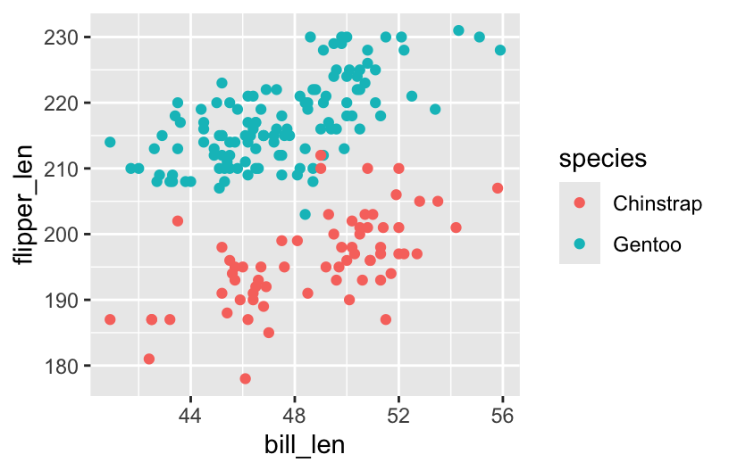

```r
penguins %>%
  ggplot(aes(y = flipper_len, x = bill_len, color = species)) +
  geom_point()
```

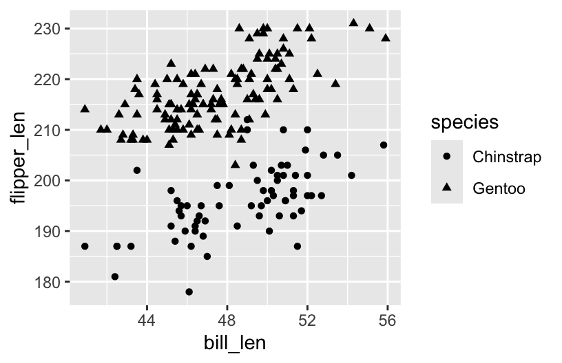

```r
penguins %>%
  ggplot(aes(y = flipper_len, x = bill_len, shape = species)) +
  geom_point()
```

## Exercise 2: Visualizing the model

```r
penguins %>%
  ggplot(aes(y = flipper_len, x = bill_len, color = species)) +
  geom_point() +
  geom_smooth(method = "lm", se = FALSE)
```

[output not shown]

## Exercise 3: Intuition

1. Gentoo tend to have longer flippers.
2. Flipper length is positively associated with bill length.
3. No. the lines are parallel / have the same slopes.

## Exercise 4: Model formula

1. `bill_len + species`
2. E[flipper_len | bill_len, speciesGentoo] = 127.75 + 1.40 * bill_len + 22.85 * speciesGentoo

## Exercise 5: Sub-model formulas

Chinstrap: flipper_len = 127.75 + 1.40 bill_len

Gentoo: flipper_len = (127.75 + 22.85) + 1.40 bill_len = 150.6 + 1.40 bill_len

## Exercise 6: coefficients – physical interpretation

1. The intercept coefficient, 127.75, is the intercept of the line for **Chinstrap** penguins.
2. The `bill_len` coefficient, 1.40, is the **slope** of both lines.
3. The `speciesGentoo` coefficient, 22.85, indicates that the **intercept** of the line for Gentoo is 22.85mm higher than the **intercept** of the line for Chinstrap. Similarly, since the lines are parallel, the line for Gentoo is 22.85mm higher than the line for Chinstrap at any `bill_len`.

## Exercise 7: coefficients – contextual interpretation

2. For both Chinstrap and Gentoo penguins, average flipper lengths increase by 1.40mm for every additional mm in bill length.
3. At any `bill_len`, the average flipper length for Gentoo penguins is 22.85mm longer than that for Chinstrap penguins.

## Exercise 8: Prediction

```r
# a
127.75 + 1.40*50 + 22.85*0
## [1] 197.75

# b
127.75 + 1.40*50 + 22.85*1
## [1] 220.6

# c
predict(penguin_mod,
        newdata = data.frame(bill_len = 50,
                             species = "Chinstrap"))
##       1
## 197.872
predict(penguin_mod,
        newdata = data.frame(bill_len = 50,
                             species = "Gentoo"))
##        1
## 220.7201
```

## Exercise 9: R-squared

1. species
2. no wrong answer
3. It’s higher than the R-squared when we use either predictor alone!